# Quantitative Datenanalyse | Fallstudie LEGO

Autor:in

Dozent:in, FOM Hochschule

Veröffentlichungsdatum

16. April 2026

# Fallstudie LEGO

**HinweisDatensatzbeschreibung**

Für diese Fallstudie arbeiten Sie mit einem bereits bereinigten LEGO-Datensatz von Peterson und Ziegler (2021). Die Daten wurden aus mehreren Quellen zu LEGO-Sets zusammengetragen und als Lehrdatensatz für statistische Analysen aufbereitet.  
Der Datensatz umfasst insgesamt 1003 Beobachtungen bei 6 Variablen.  
Die Beobachtungseinheit des Datensatzes ist jeweils ein LEGO-Set.  
In der vorliegenden Fallstudie beschränken wir uns auf die Variablen `Item_Number`, `Set_Name`, `Price`, `Pieces`, `Theme` und `Size`.

`Item_Number` beschreibt die jeweilige Identifikationsnummer des Sets,

`Set_Name` den Namen des Sets,

`Price` den empfohlenen Verkaufspreis des Sets,

`Pieces` die Anzahl der enthaltenen Teile,

`Theme` die Themenwelt des Sets und

`Size` die Größenkategorie der LEGO-Sets.

Auf dieser Grundlage bearbeiten Sie im Folgenden Aufgaben zur explorativen Datenanalyse, zur Normalverteilung sowie zur einfachen und multiplen linearen Regression einschließlich eines kurzen inferenzstatistischen Teils.

## 1. Datenverständnis

### 1.1 Datensatz und Pakete laden

Laden Sie den bereitgestellten bereinigten Datensatz und die benötigten Pakete. Nutzen Sie hierfür den unten bereitgestellten Code. Falls notwendig, installieren Sie die untenstehenden Pakete vorab.

```r
# Benötigte Pakete laden
library(mosaic)
library(tidyr)
library(here)
# Datensatz einlesen
lego <- read.csv(
  here::here("lego_population_qmd.csv"),
  stringsAsFactors = TRUE
)
```

#### Lösung 1.1

```r
# Benötigte Pakete laden
library(mosaic)
library(tidyr)
library(here)

# Datensatz einlesen
lego <- read.csv(
  here::here("lego_population_qmd.csv"),
  stringsAsFactors = TRUE
)

# Struktur des Datensatzes anzeigen
str(lego)
```

```
'data.frame':   1003 obs. of  6 variables:
 $ Item_Number: int  41916 41908 11006 11007 41901 41902 41903 41911 41912 41917 ...
 $ Set_Name   : Factor w/ 979 levels "1967 Mini Cooper S Rally and 2018 MINI John Cooper Works Buggy",..: 293 292 188 190 338 762 186 353 486 492 ...
 $ Price      : num  3.99 3.99 4.99 4.99 4.99 4.99 4.99 4.99 4.99 4.99 ...
 $ Pieces     : int  109 109 52 60 33 33 33 33 33 33 ...
 $ Theme      : Factor w/ 40 levels "Architecture",..: 10 10 5 5 10 10 10 10 10 10 ...
 $ Size       : Factor w/ 2 levels "Large","Small": 2 2 2 2 2 2 2 2 2 2 ...
```

```r
# Erste Fälle des Datensatzes anzeigen
head(lego)
```

```
  Item_Number                 Set_Name Price Pieces   Theme  Size
1       41916    Extra Dots - Series 2  3.99    109    DOTS Small
2       41908    Extra Dots - Series 1  3.99    109    DOTS Small
3       11006     Creative Blue Bricks  4.99     52 Classic Small
4       11007    Creative Green Bricks  4.99     60 Classic Small
5       41901   Funky Animals Bracelet  4.99     33    DOTS Small
6       41902 Sparkly Unicorn Bracelet  4.99     33    DOTS Small
```

Der Datensatz wurde eingelesen und steht nun im Objekt `lego` zur Verfügung. Die Strukturübersicht zeigt, welche Variablen im Datensatz enthalten sind und in welchem Format sie vorliegen.  
Die Ausgabe der ersten Fälle ermöglicht einen schnellen ersten Eindruck von den Beobachtungseinheiten und den enthaltenen Werten.

### 1.2 Skalenniveau bestimmen

Bestimmen Sie für die Variablen `Price`, `Pieces`, `Theme` und `Size` jeweils das Skalenniveau und begründen Sie jede Zuordnung in einem kurzen Satz.

#### Lösung 1.2

```r
# Price: metrisch, verhältnisskaliert
# Pieces: metrisch, verhältnisskaliert
# Theme: kategorial, nominalskaliert
# Size: kategorial, nominalskaliert
```

Mögliche Antwortsätze: `Price` ist metrisch und verhältnisskaliert, weil Preise numerisch gemessen werden und ein sinnvoll interpretierbarer Nullpunkt vorliegt.  
`Pieces` ist ebenfalls metrisch und verhältnisskaliert, weil die Anzahl der Teile gezählt wird und Verhältnisse wie „doppelt so viele Teile“ sinnvoll sind.  
`Theme` ist kategorial und nominalskaliert, weil die Themenwelten verschiedene Kategorien ohne natürliche Rangordnung darstellen.  
`Size` ist ebenfalls kategorial und nominalskaliert, weil auch die Größenkategorien lediglich Gruppen bezeichnen und keine Rangfolge ausdrücken.

## 2. Explorative Datenanalyse von `Theme`

### 2.1 Häufigkeitstabelle erstellen

Analysieren Sie ausschließlich die Variable `Theme`. Erstellen Sie eine Häufigkeitstabelle, die für jede Kategorie die absolute und relative Häufigkeit enthält.

#### Lösung 2.1

```r
# Absolute Häufigkeiten von Theme berechnen
theme_abs <- tally(~ Theme, data = lego)

# Relative Häufigkeiten von Theme berechnen
theme_rel <- tally(~ Theme, data = lego, format = "proportion")

# Beide Häufigkeiten in einer gemeinsamen Tabelle zusammenführen (für bessere Übersicht)
theme_tab <- data.frame(
  Theme = names(theme_abs),
  Absolut = as.vector(theme_abs),
  Relativ = as.vector(theme_rel)
)

# Tabelle ausgeben
theme_tab
```

```
                 Theme Absolut     Relativ
1         Architecture      11 0.010967099
2               Batman      16 0.015952144
3           BrickHeadz      33 0.032901296
4                 City     100 0.099700897
5              Classic      21 0.020937188
6       Creator 3-in-1      38 0.037886341
7       Creator Expert      15 0.014955135
8                   DC      11 0.010967099
9               Disney      43 0.042871386
10                DOTS      18 0.017946162
11               DUPLO      52 0.051844467
12             Friends     101 0.100697906
13        Harry Potter      26 0.025922233
14         Hidden Side      19 0.018943170
```

[output cut: 26 more lines]

Die generierte Tabelle zeigt für jede Themenkategorie, wie oft sie in der Stichprobe vorkommt und welchen Anteil sie an allen LEGO-Sets hat.  
Die absoluten Häufigkeiten machen sichtbar, welche Themen oft oder selten vertreten sind.  
Die relativen Häufigkeiten erleichtern zusätzlich die Einschätzung der Verteilung unabhängig von der Stichprobengröße.

### 2.2 Balkendiagramm erstellen

Erstellen Sie ein Balkendiagramm der absoluten Häufigkeiten von `Theme`.

#### Lösung 2.2

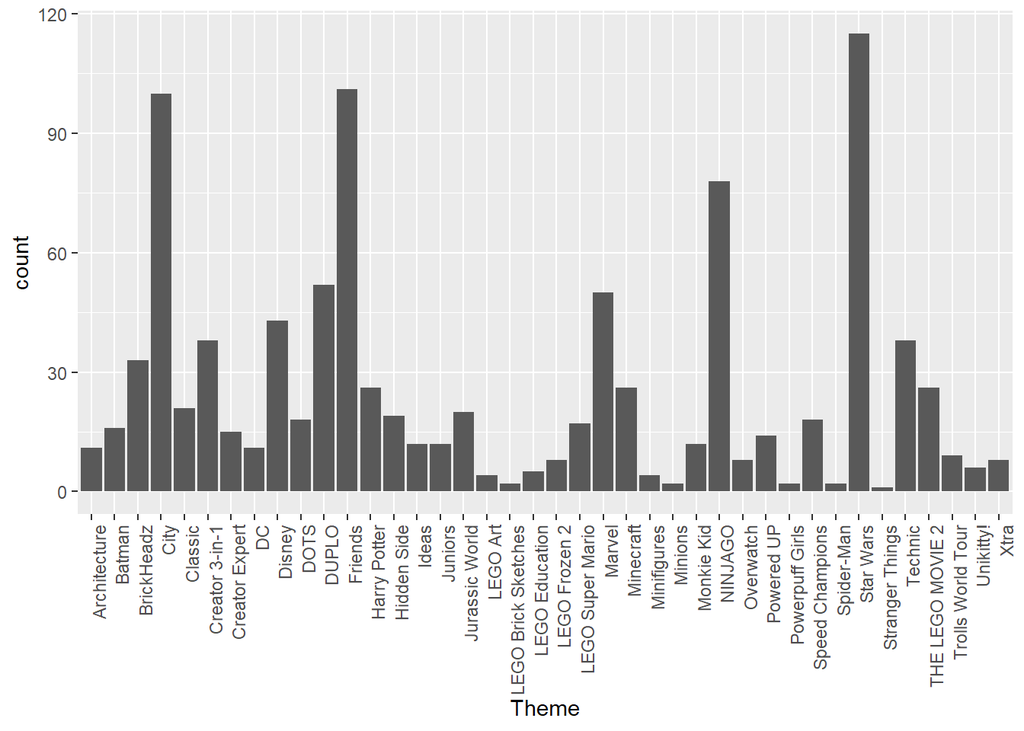

```r
# Balkendiagramm der absoluten Häufigkeiten von Theme erstellen
gf_bar(~ Theme, data = lego) |>
  # Textanpassung für bessere Lesbarkeit
  gf_theme(axis.text.x = element_text(angle = 90, hjust = 1))
```

Das Balkendiagramm visualisiert die absoluten Häufigkeiten der einzelnen Themenkategorien.  
Je höher ein Balken ist, desto häufiger ist die entsprechende Kategorie in der Stichprobe vertreten.  
Die grafische Darstellung ergänzt die Häufigkeitstabelle und erleichtert den schnellen Vergleich zwischen den Kategorien.

### 2.3 Verteilung beschreiben

Beschreiben Sie die Verteilung von `Theme` auf Basis der Tabelle und des Balkendiagramms. Gehen Sie dabei ausdrücklich auf die Anzahl der Kategorien, die häufigste Kategorie und die Frage ein, ob sich die Stichprobe eher auf wenige Themen konzentriert oder breit über viele Themen verteilt.

#### Lösung 2.3

Die Variable `Theme` umfasst 40 Kategorien. Die häufigste Kategorie ist `Star Wars` mit einer absoluten Häufigkeit von 115 Sets beziehungsweise einem relativen Anteil von 11,5 Prozent. Die Verteilung ist nicht vollständig gleichmäßig, weil einige Themen deutlich häufiger vertreten sind als andere. Damit konzentriert sich die Stichprobe eher auf einige stärker vertretene Themen, während andere Themen nur mit wenigen Sets vorkommen.

## 3. Explorative Datenanalyse von `Price`

### 3.1 Kennwerte berechnen

Analysieren Sie ausschließlich die Variable `Price`.

Berechnen Sie für `Price` die folgenden Kennwerte: Mittelwert, Median, Standardabweichung, Minimum, Maximum, 25%-Quantil, 75%-Quantil und Interquartilsabstand.

#### Lösung 3.1

```r
# Zentrale Kennwerte für Price berechnen
price_stats <- favstats(~ Price, data = lego)
price_stats
```

```
  min    Q1 median    Q3    max     mean       sd    n missing
 3.49 14.99  29.99 59.99 699.99 47.81931 60.15527 1003       0
```

```r
# Interquartilsabstand
price_stats$Q3 - price_stats$Q1
```

```
[1] 45
```

Die berechneten Kennwerte beschreiben die Preisverteilung in kompakter Form.  
Mittelwert und Median geben die Lage der Verteilung an, während Standardabweichung und Interquartilsabstand Informationen über die Streuung liefern.  
Minimum, Maximum sowie die Quartile ergänzen diese Beschreibung um Angaben zur Spannweite und zur Verteilung der mittleren 50 Prozent der Werte.

### 3.2 Histogramm erstellen

Erstellen Sie ein Histogramm von `Price`.

#### Lösung 3.2

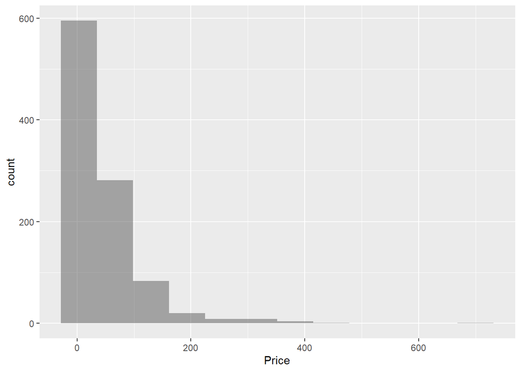

```r
# Histogramm zur Verteilung von Price erstellen
gf_histogram(~ Price, data = lego, bins = 12)
```

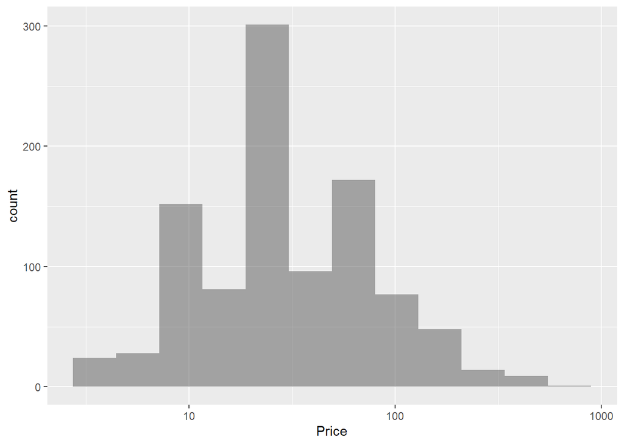

```r
# mit Logarithmischer x-Achse für bessere Darstellung
gf_histogram(~ Price, data = lego, bins = 12) +
  scale_x_log10()
```

Das Histogramm zeigt, wie sich die Preiswerte über verschiedene Wertebereiche verteilen. So lässt sich erkennen, ob viele Werte in einem ähnlichen Bereich liegen oder ob die Verteilung eher breit gestreut ist. Außerdem erlaubt das Histogramm eine erste Einschätzung dazu, ob die Verteilung eher symmetrisch oder eher schief ist.

### 3.3 Boxplot erstellen

Erstellen Sie einen Boxplot von `Price`.

#### Lösung 3.3

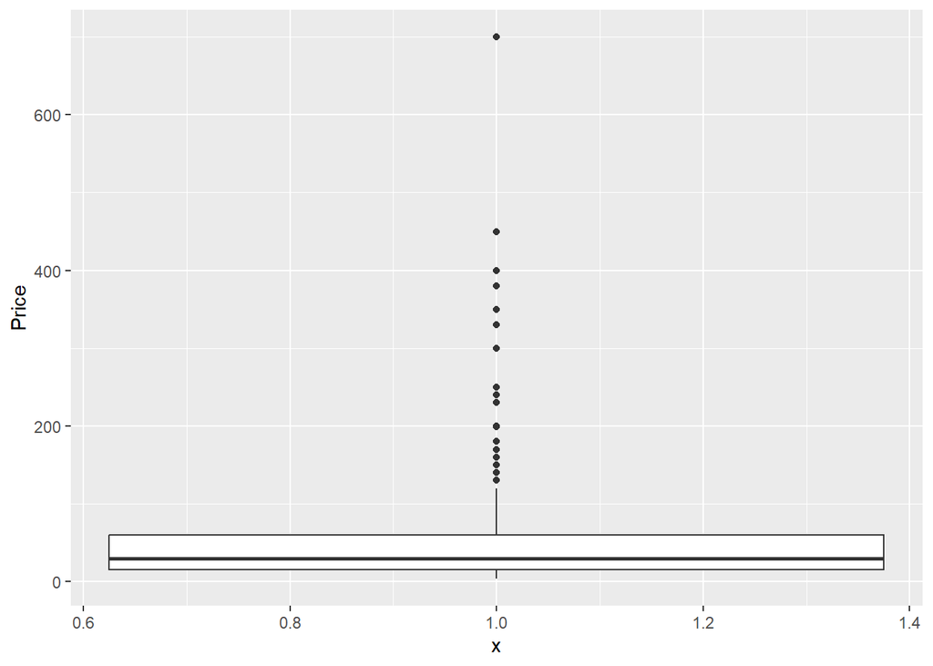

```r
# Boxplot für Price erstellen
gf_boxplot(Price ~ 1, data = lego)
```

Der Boxplot stellt Median, Quartile und mögliche auffällige Einzelwerte übersichtlich dar. Insbesondere lassen sich damit potenzielle Ausreißer erkennen, die deutlich außerhalb des zentralen Wertebereichs liegen. Zusammen mit dem Histogramm ergibt sich so ein anschauliches Gesamtbild der Preisverteilung.

### 3.4 Verteilung beschreiben

Beschreiben Sie die Verteilung von `Price`. Gehen Sie dabei auf die Lage anhand von Mittelwert und Median, die Streuung anhand von Standardabweichung und Interquartilsabstand, mögliche Schiefe anhand des Histogramms sowie mögliche Ausreißer anhand des Boxplots ein.

#### Lösung 3.4

```r
# Bereits berechnete Kennwerte noch einmal kompakt ausgeben
price_stats
```

```
  min    Q1 median    Q3    max     mean       sd    n missing
 3.49 14.99  29.99 59.99 699.99 47.81931 60.15527 1003       0
```

Die Preisverteilung ist deutlich rechtsschief. Darauf weist insbesondere hin, dass der Mittelwert von 47,82 USD merklich über dem Median von 29,99 USD liegt. Zugleich zeigt die Standardabweichung von 60,16 USD eine erhebliche Streuung der Preise. Auch der Interquartilsabstand von 45,00 USD verdeutlicht, dass die mittleren 50% der Werte relativ breit zwischen 14,99 USD und 59,99 USD verteilt sind. Das Histogramm gibt Aufschluss über die Form der Verteilung und zeigt insbesondere, dass viele niedrige und nur wenige sehr hohe Preise vorkommen. Der Boxplot ergänzt diese Einschätzung, indem er die Ausreißer als Werte außerhalb der Whisker sichtbar macht. Die große Differenz zwischen dem Minimalwert von 3,49 USD und dem Maximalwert von 699,99 USD spricht zusätzlich dafür, dass wenige sehr hohe Preise die Verteilung nach oben ausdehnen.

## 4. Normalverteilung und einfache lineare Regression

### 4.1 Normalverteilung

Verwenden Sie weiterhin `Price` und nutzen Sie den in Aufgabe 3 berechneten Mittelwert sowie die Standardabweichung als Parameter einer theoretischen Normalverteilung.

Berechnen Sie den z-Wert für `Price = 100`, interpretieren Sie ihn in einem Satz und bestimmen Sie anschließend das 95%-Quantil sowie eine grobe Einordnung von 100 USD mit der 68-95-99,7-Regel.

#### Lösung 4.1

```r
# Mittelwert und Standardabweichung von Price berechnen
mu_price <- mean(~ Price, data = lego)
sd_price <- sd(~ Price, data = lego)

# z-Wert für Price = 100 berechnen
z_100 <- (100 - mu_price) / sd_price
z_100
```

```
[1] 0.8674334
```

```r
# 95%-Quantil der theoretischen Normalverteilung berechnen
q95_price <- qnorm(p = 0.95, mean = mu_price, sd = sd_price)
q95_price
```

```
[1] 146.7659
```

```r
# Grenzen der 68-95-99,7-Regel berechnen
rule_68 <- c(mu_price - sd_price, mu_price + sd_price)
rule_95 <- c(mu_price - 2 * sd_price, mu_price + 2 * sd_price)
rule_997 <- c(mu_price - 3 * sd_price, mu_price + 3 * sd_price)

rule_68
```

```
[1] -12.33596 107.97458
```

```r
rule_95
```

```
[1] -72.49123 168.12985
```

```r
rule_997
```

```
[1] -132.6465  228.2851
```

```
If X ~ N(47.82, 60.16), then
```

```
    P(X <= 100) = P(Z <= 0.8674) = 0.8071
```

```
    P(X >  100) = P(Z >  0.8674) = 0.1929
```

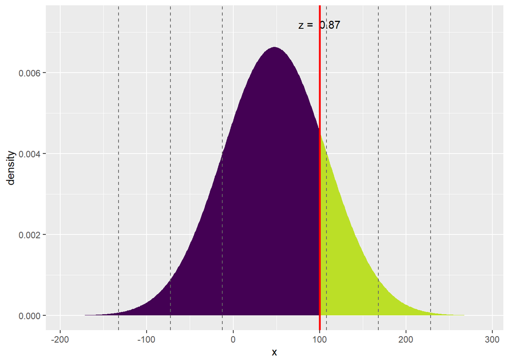

```r
xpnorm(
  q = 100,
  mean = mu_price,
  sd = sd_price,
  return = "plot",
  system = "gg"
) |>
  gf_vline(
    xintercept = c(rule_68, rule_95, rule_997),
    color = "gray40",
    linetype = "dashed"
  ) |>
  gf_vline(
    xintercept = 100,
    color = "red",
    linewidth = 1
  )
```

Der z-Wert für Price = 100 beträgt 0.87. Damit liegt ein Preis von 100 USD über dem Mittelwert der theoretischen Normalverteilung, aber weniger als eine Standardabweichung darüber und ist daher als überdurchschnittlich, jedoch nicht außergewöhnlich hoch einzuordnen. Die Wahrscheinlichkeit P(X≤100) beträgt rund 0.807, sodass etwa 80.7% der Werte der theoretischen Verteilung bei höchstens 100 USD liegen.

Das 95%-Quantil liegt bei 146.77 USD; ein Preis von 100 USD gehört damit nicht zu den teuersten 5% der Werte. Nach der 68-95-99,7-Regel liegt 100 USD noch innerhalb des 1σ-Bereichs (siehe Plot). Da die dabei berechneten unteren Intervallgrenzen negativ werden, wird zugleich deutlich, dass die Normalverteilung für Preise nur eine vereinfachende theoretische Annahme darstellt.

### 4.2 Zusammenhang zwischen `Pieces` und `Price`

Untersuchen Sie danach den Zusammenhang zwischen `Pieces` und `Price`: Erstellen Sie ein Streudiagramm mit `Pieces` auf der x-Achse und `Price` auf der y-Achse, berechnen Sie die Pearson-Korrelation und beschreiben Sie Richtung und Stärke des Zusammenhangs.

#### Lösung 4.2

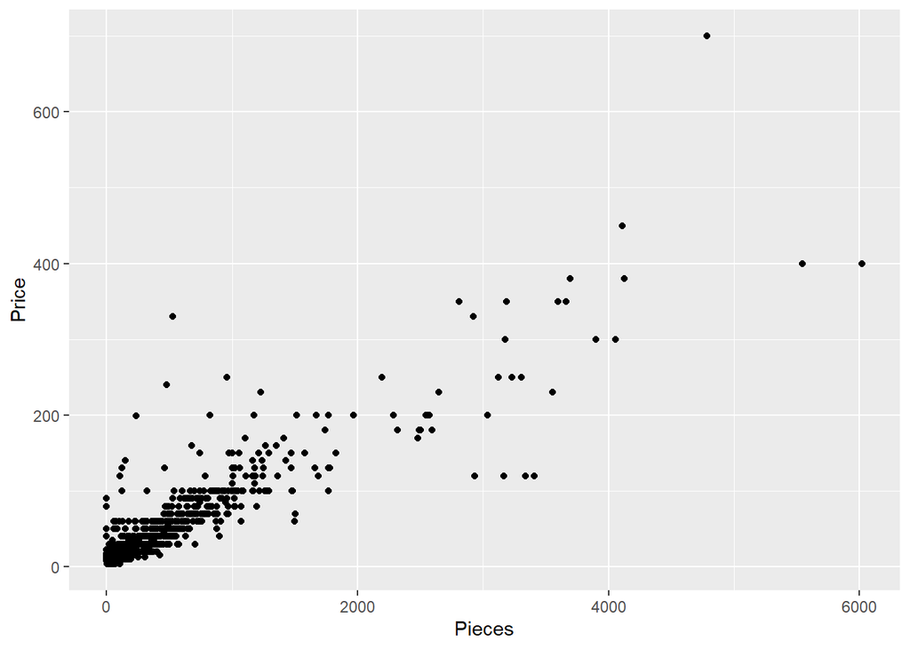

```r
# Streudiagramm zwischen Pieces und Price erstellen
gf_point(Price ~ Pieces, data = lego)
```

```r
# Pearson-Korrelation zwischen Pieces und Price berechnen
r_pieces_price <- cor(Price ~ Pieces, data = lego)
r_pieces_price
```

```
[1] 0.8912873
```

Die Pearson-Korrelation zwischen Pieces und Price beträgt 0.891. Da der Korrelationskoeffizient positiv und betragsmäßig hoch ist, besteht ein starker positiver linearer Zusammenhang zwischen Teilezahl und Preis. Inhaltlich bedeutet dies, dass LEGO-Sets mit mehr Teilen tendenziell teurer sind.

Das Streudiagramm bestätigt diesen Befund, da die Punktwolke insgesamt eine deutlich ansteigende Tendenz zeigt. Je enger die Punkte um eine gedachte Gerade liegen, desto stärker ist der lineare Zusammenhang; hier ist ein klarer positiver Zusammenhang erkennbar, auch wenn die Punkte insbesondere bei höheren Teilezahlen nicht perfekt auf einer Linie liegen. Zudem nimmt die Streuung im oberen Bereich der Teilezahl sichtbar zu, und einzelne sehr große Sets liegen deutlich oberhalb des Hauptclusters.

### 4.3 Einfache lineare Regression

Schätzen Sie das lineare Regressionsmodell `Price ~ Pieces`, geben Sie die geschätzte Regressionsgleichung an, interpretieren Sie Konstante und Steigung jeweils in einem eigenen Satz, berichten Sie (R^2) und berechnen Sie die Punktprognose für ein Set mit `Pieces = 500`.

#### Lösung 4.3

```r
# Einfaches lineares Regressionsmodell schätzen
mod1 <- lm(Price ~ Pieces, data = lego)

# Modellzusammenfassung ausgeben
summary(mod1)
```

```
Call:
lm(formula = Price ~ Pieces, data = lego)

Residuals:
     Min       1Q   Median       3Q      Max
-170.849   -9.976   -4.974    4.975  296.177

Coefficients:
             Estimate Std. Error t value Pr(>|t|)
(Intercept) 11.602400   1.040042   11.16   <2e-16 ***
Pieces       0.081984   0.001318   62.19   <2e-16 ***
---
Signif. codes:  0 '***' 0.001 '**' 0.01 '*' 0.05 '.' 0.1 ' ' 1

Residual standard error: 27.29 on 1001 degrees of freedom
Multiple R-squared:  0.7944,    Adjusted R-squared:  0.7942
F-statistic:  3868 on 1 and 1001 DF,  p-value: < 2.2e-16
```

```r
# Gleichung zur Berechnung der Prognose für ein Set mit 500
11.6024 + 0.081984 * 500
```

```
[1] 52.5944
```

Die Konstante von 11.602 gibt den geschätzten Preis für ein hypothetisches LEGO-Set mit 0 Teilen an. Inhaltlich ist dieser Wert vor allem als rechnerischer Ausgangspunkt der Regressionsgeraden zu verstehen, da ein Set mit 0 Teilen praktisch keine sinnvolle inhaltliche Interpretation hat.

Die Steigung von 0.082 bedeutet, dass sich der erwartete Preis im Mittel um 0.082 USD erhöht, wenn die Teilezahl um ein weiteres Teil zunimmt. Mit anderen Worten: LEGO-Sets mit mehr Teilen sind im Mittel teurer, und pro zusätzlichem Teil steigt der geschätzte Preis um rund 8.2 Cent.

Das Bestimmtheitsmaß beträgt 0.794. Damit werden 79.4% der Varianz von Price durch die Variable Pieces erklärt.

Für ein LEGO-Set mit 500 Teilen ergibt sich die Punktprognose:

Price = 11.602 + 0.082 ⋅ 500 = 52.59.

Der vorhergesagte Preis für ein Set mit 500 Teilen beträgt somit rund 52.59 USD.

## 5. Multiple Regression und Inferenz

### 5.1 Regression mit kategorialer unabhängiger Variable

Schätzen Sie zunächst das Modell `Price ~ Size`. Legen Sie dafür vorab die Ausprägung “Small” der Variable “Size” mit dem untenstehenden Code als Referenzkategorie fest.

Interpretieren Sie den Koeffizienten der Nicht-Referenzkategorie als mittleren Preisunterschied zur Referenzkategorie.

```r
# Die Kategorie "Small" für die Variable "Size" als Referenzkategorie festlegen
lego$Size <- factor(lego$Size, levels = c("Small", "Large"))
```

#### Lösung 5.1

```r
# Die Kategorie "Small" für die Variable "Size" als Referenzkategorie festlegen
lego$Size <- factor(lego$Size, levels = c("Small", "Large"))

# Regressionsmodell mit der kategorialen Variable Size schätzen
mod_size <- lm(Price ~ Size, data = lego)

# Modellzusammenfassung ausgeben
summary(mod_size)
```

```
Call:
lm(formula = Price ~ Size, data = lego)

Residuals:
   Min     1Q Median     3Q    Max
-44.77 -33.77 -18.77  11.23 651.23

Coefficients:
            Estimate Std. Error t value Pr(>|t|)
(Intercept)   48.762      1.947  25.041   <2e-16 ***
SizeLarge    -18.175      8.552  -2.125   0.0338 *
---
Signif. codes:  0 '***' 0.001 '**' 0.01 '*' 0.05 '.' 0.1 ' ' 1

Residual standard error: 60.05 on 1001 degrees of freedom
Multiple R-squared:  0.004492,  Adjusted R-squared:  0.003497
F-statistic: 4.517 on 1 and 1001 DF,  p-value: 0.03381
```

Die Referenzkategorie ist `Small`, sodass die Konstante von 48,762 den geschätzten mittleren Preis von LEGO-Sets der Kategorie `Small` angibt. Der Koeffizient von `SizeLarge` beträgt -18,175 und bedeutet, dass `Large`-Sets in diesem bivariaten Modell, ohne Kontrolle weiterer Faktoren, im Mittel 18,175 USD günstiger sind als `Small`-Sets. Da der p-Wert 0,03381 beträgt, ist dieser Unterschied auf dem 5%-Niveau statistisch signifikant. Das Bestimmtheitsmaß von 0,004492 zeigt jedoch, dass `Size` allein nur einen sehr kleinen Teil der Preisunterschiede erklärt.

### 5.2 Multiple lineare Regression

Schätzen Sie anschließend das multiple lineare Regressionsmodell `Price ~ Pieces + Size` und interpretieren Sie die Koeffizienten von `Pieces` und `Size` inhaltlich.

#### Lösung 5.2

```r
# Multiples lineares Regressionsmodell schätzen
mod_multi <- lm(Price ~ Pieces + Size, data = lego)

# Modellzusammenfassung ausgeben
summary(mod_multi)
```

```
Call:
lm(formula = Price ~ Pieces + Size, data = lego)

Residuals:
     Min       1Q   Median       3Q      Max
-172.370   -9.269   -4.370    4.337  293.549

Coefficients:
             Estimate Std. Error t value Pr(>|t|)
(Intercept) 10.385873   1.069872   9.708  < 2e-16 ***
Pieces       0.082787   0.001321  62.690  < 2e-16 ***
SizeLarge   16.618134   3.893344   4.268 2.16e-05 ***
---
Signif. codes:  0 '***' 0.001 '**' 0.01 '*' 0.05 '.' 0.1 ' ' 1

Residual standard error: 27.06 on 1000 degrees of freedom
Multiple R-squared:  0.7981,    Adjusted R-squared:  0.7977
F-statistic:  1976 on 2 and 1000 DF,  p-value: < 2.2e-16
```

Die geschätzte Regressionsgleichung lautet: Price = 10,386 + 0,082787 ⋅ Pieces + 16,618 ⋅ SizeLarge. Die Konstante von 10,386 gibt den geschätzten Preis für ein `Small`-Set mit 0 Teilen an und ist vor allem als rechnerischer Ausgangspunkt des Modells zu verstehen.

Der Koeffizient von `Pieces` beträgt 0,082787. Das bedeutet: Wenn die Teilezahl um ein Teil steigt und die Größe des Sets gleich bleibt, erhöht sich der erwartete Preis im Mittel um 0,082787 USD. Anders ausgedrückt steigt der geschätzte Preis bei 100 zusätzlichen Teilen im Mittel um 8,279 USD, wenn `Size` konstant gehalten wird.

Der Koeffizient von `SizeLarge` beträgt 16,618. Das bedeutet, dass `Large`-Sets bei gleicher Teilezahl im Mittel um 16,618 USD teurer sind als `Small`-Sets. Dieser Unterschied ist statistisch signifikant, da der p-Wert 0,0000216 beträgt.

Das Bestimmtheitsmaß des multiplen Modells beträgt 0,7981. Somit erklären `Pieces` und `Size` gemeinsam 79,81 Prozent der Varianz des Preises. Im Vergleich zum einfachen Modell mit nur `Size` zeigt sich damit, dass vor allem die Teilezahl ein zentraler Prädiktor des Preises ist, während `Size` darüber hinaus einen zusätzlichen eigenständigen Beitrag leistet.

Der Koeffizient von `SizeLarge` verändert sich gegenüber dem bivariaten Modell aus 5.1 deutlich. Dort war `Large` mit einem niedrigeren durchschnittlichen Preis verbunden, während im multiplen Modell bei Kontrolle der Teilezahl ein positiver Effekt von 16,618 USD sichtbar wird. Das zeigt, dass der einfache Mittelwertvergleich zwischen `Small` und `Large` durch Unterschiede in der Teilezahl verzerrt war und dass Large-Sets bei gleicher Teilezahl im Mittel teurer sind.

### 5.3 Inferenz

Formulieren Sie für den Koeffizienten von `SizeLarge` die Nullhypothese und die Alternativhypothese. Geben Sie den p-Wert an und entscheiden Sie auf dem 5%-Niveau, ob sich `Large`- und `Small`-Sets bei gleicher Teilezahl statistisch bedeutsam im Preis unterscheiden. Bestimmen Sie außerdem mithilfe eines Bootstrap-Verfahrens ein 95%-Konfidenzintervall für den Koeffizienten von `SizeLarge` und interpretieren Sie dieses Intervall als plausiblen Bereich für den Preisunterschied zwischen beiden Größenkategorien.

#### Lösung 5.3

```r
# p-Wert für den Koeffizienten von SizeLarge aus dem multiplen Modell extrahieren
p_size <- summary(mod_multi)$coefficients["SizeLarge", "Pr(>|t|)"]
# Ungekürzte Ausgabe zur besseren Veranschaulichung
format(p_size, scientific = FALSE)
```

```
[1] "0.00002156554"
```

```r
# Zufallsstartwert setzen, damit die Bootstrap-Ergebnisse reproduzierbar sind
set.seed(12345)

# Bootstrap-Stichproben ziehen und jeweils den Koeffizienten schätzen
boot_multi <- do(1000) * coef(lm(Price ~ Pieces + Size, data = resample(lego)))

# 95%-Konfidenzintervall für den Koeffizienten von SizeLarge bestimmen
ki_size <- qdata(~ SizeLarge, p = c(0.025, 0.975), data = boot_multi)
ki_size
```

```
     2.5%     97.5%
 9.519242 24.195975
```

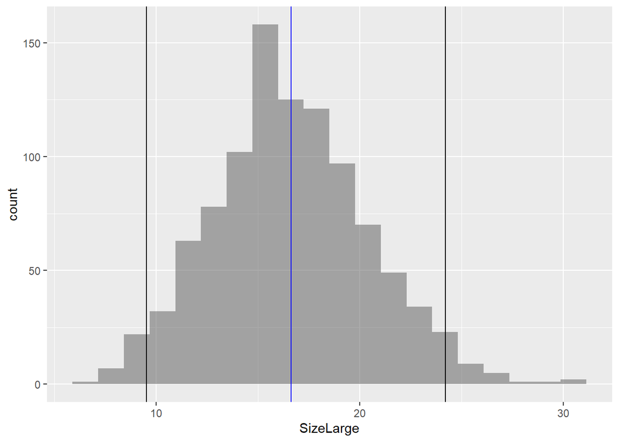

```r
# Bootstrap-Verteilung des Koeffizienten von SizeLarge als Histogramm darstellen
gf_histogram(~ SizeLarge, data = boot_multi, bins = 20,
            center = coef(mod_multi)["SizeLarge"]) |>

  # Grenzen des 95%-Konfidenzintervalls einzeichnen
  gf_vline(xintercept = ki_size) |>

  # Geschätzten Koeffizienten aus dem Originalmodell zusätzlich markieren
  gf_vline(xintercept = coef(mod_multi)["SizeLarge"], color = "blue")
```

Die Nullhypothese lautet H_0: Der Koeffizient von `SizeLarge` ist gleich 0.

Die Alternativhypothese lautet H_A : Der Koeffizient von `SizeLarge` ist ungleich 0.

Der p-Wert beträgt 0.00002156554. Da dieser Wert deutlich kleiner als 0.05 ist, wird die Nullhypothese auf dem 5%-Niveau verworfen.

Damit spricht das Ergebnis dafür, dass sich `Large`- und `Small`-Sets bei gleicher Teilezahl statistisch bedeutsam im Preis unterscheiden.

Das 95%-Konfidenzintervall für den Koeffizienten von `SizeLarge` reicht von 9.52 bis 24.20. Dieses Intervall kann als plausibler Bereich für den Preisunterschied zwischen `Large`- und `Small`-Sets bei gleicher Teilezahl interpretiert werden.

Inhaltlich bedeutet das: Bei gleicher Anzahl an Teilen sind `Large`-Sets im Mittel schätzungsweise zwischen 9.52 USD und 24.20 USD teurer als Small-Sets. Da der Wert 0 nicht im Intervall enthalten ist, spricht auch das Konfidenzintervall für einen statistisch bedeutsamen Unterschied zwischen den beiden Größenkategorien.